# projet9

```python
import pandas as pd
dossier = "C:/Users/smaki/OneDrive/Bureau/DATA ANALYST/projet 9/"
```

```python
import numpy as np
import matplotlib.pyplot as plt
import seaborn as sns
import scipy.stats as stats
```

```python
df_products = pd.read_excel(dossier + "products1.xlsx")
df_products.head()
```

|  | id_prod | price | categ |
| --- | --- | --- | --- |
| 0 | 0_1421 | 19.99 | 0 |
| 1 | 0_1368 | 5.13 | 0 |
| 2 | 0_731 | 17.99 | 0 |
| 3 | 1_587 | 4.99 | 1 |
| 4 | 0_1507 | 3.99 | 0 |

```python
df_products.info()
```

```
<class 'pandas.core.frame.DataFrame'>
RangeIndex: 3286 entries, 0 to 3285
Data columns (total 3 columns):
 #   Column   Non-Null Count  Dtype
---  ------   --------------  -----
 0   id_prod  3286 non-null   object
 1   price    3286 non-null   float64
 2   categ    3286 non-null   int64
dtypes: float64(1), int64(1), object(1)
memory usage: 77.1+ KB
```

```python
mask_price = df_products.price <= 0
df_products[mask_price]
```

|  | id_prod | price | categ |
| --- | --- | --- | --- |

```python
df_customers = pd.read_excel(dossier + "customers1.xlsx")
df_customers.head()
```

|  | client_id | sex | birth |
| --- | --- | --- | --- |
| 0 | c_4410 | f | 1967 |
| 1 | c_7839 | f | 1975 |
| 2 | c_1699 | f | 1984 |
| 3 | c_5961 | f | 1962 |
| 4 | c_5320 | m | 1943 |

```python
df_customers.info()
```

```
<class 'pandas.core.frame.DataFrame'>
RangeIndex: 8621 entries, 0 to 8620
Data columns (total 3 columns):
 #   Column     Non-Null Count  Dtype
---  ------     --------------  -----
 0   client_id  8621 non-null   object
 1   sex        8621 non-null   object
 2   birth      8621 non-null   int64
dtypes: int64(1), object(2)
memory usage: 202.2+ KB
```

```python
df_transactions = pd.read_excel(dossier + "Transactions1.xlsx")
df_transactions.info()
```

```
<class 'pandas.core.frame.DataFrame'>
RangeIndex: 687534 entries, 0 to 687533
Data columns (total 4 columns):
 #   Column      Non-Null Count   Dtype
---  ------      --------------   -----
 0   id_prod     687534 non-null  object
 1   date        687534 non-null  object
 2   session_id  687534 non-null  object
 3   client_id   687534 non-null  object
dtypes: object(4)
memory usage: 21.0+ MB
```

```python
df_transactions.head()
```

|  | id_prod | date | session_id | client_id |
| --- | --- | --- | --- | --- |
| 0 | 0_1259 | 2021-03-01 00:01:07.843138 | s_1 | c_329 |
| 1 | 0_1390 | 2021-03-01 00:02:26.047414 | s_2 | c_664 |
| 2 | 0_1352 | 2021-03-01 00:02:38.311413 | s_3 | c_580 |
| 3 | 0_1458 | 2021-03-01 00:04:54.559692 | s_4 | c_7912 |
| 4 | 0_1358 | 2021-03-01 00:05:18.801198 | s_5 | c_2033 |

```python
mask_vide = df_transactions.session_id.isna()
df_transactions[mask_vide]
```

|  | id_prod | date | session_id | client_id |
| --- | --- | --- | --- | --- |

```python
df_custom_transac = pd.merge(df_transactions,df_customers,how="outer",right_on="client_id",left_on="client_id",indicator=True )
df_custom_transac.head()
```

|  | id_prod | date | session_id | client_id | sex | birth | _merge |
| --- | --- | --- | --- | --- | --- | --- | --- |
| 0 | 0_1259 | 2021-03-01 00:01:07.843138 | s_1 | c_329 | f | 1967 | both |
| 1 | 1_498 | 2021-03-11 00:57:22.865244 | s_4624 | c_329 | f | 1967 | both |
| 2 | 0_1140 | 2021-03-16 10:01:30.705174 | s_7071 | c_329 | f | 1967 | both |
| 3 | 1_451 | 2021-03-18 17:26:18.887580 | s_8134 | c_329 | f | 1967 | both |
| 4 | 1_381 | 2021-04-25 13:26:06.218857 | s_25561 | c_329 | f | 1967 | both |

```python
mask_left =df_custom_transac._merge =="left_only"
df_custom_transac[mask_left]
```

|  | id_prod | date | session_id | client_id | sex | birth | _merge |
| --- | --- | --- | --- | --- | --- | --- | --- |

```python
mask_right =df_custom_transac._merge =="right_only"
df_custom_transac[mask_right]
```

|  | id_prod | date | session_id | client_id | sex | birth | _merge |
| --- | --- | --- | --- | --- | --- | --- | --- |
| 687534 | NaN | NaN | NaN | c_8253 | f | 2001 | right_only |
| 687535 | NaN | NaN | NaN | c_3789 | f | 1997 | right_only |
| 687536 | NaN | NaN | NaN | c_4406 | f | 1998 | right_only |
| 687537 | NaN | NaN | NaN | c_2706 | f | 1967 | right_only |
| 687538 | NaN | NaN | NaN | c_3443 | m | 1959 | right_only |
| 687539 | NaN | NaN | NaN | c_4447 | m | 1956 | right_only |
| 687540 | NaN | NaN | NaN | c_3017 | f | 1992 | right_only |
| 687541 | NaN | NaN | NaN | c_4086 | f | 1992 | right_only |
| 687542 | NaN | NaN | NaN | c_6930 | m | 2004 | right_only |
| 687543 | NaN | NaN | NaN | c_4358 | m | 1999 | right_only |
| 687544 | NaN | NaN | NaN | c_8381 | f | 1965 | right_only |
| 687545 | NaN | NaN | NaN | c_1223 | m | 1963 | right_only |
| 687546 | NaN | NaN | NaN | c_6862 | f | 2002 | right_only |
| 687547 | NaN | NaN | NaN | c_5245 | f | 2004 | right_only |
| 687548 | NaN | NaN | NaN | c_5223 | m | 2003 | right_only |
| 687549 | NaN | NaN | NaN | c_6735 | m | 2004 | right_only |
| 687550 | NaN | NaN | NaN | c_862 | f | 1956 | right_only |
| 687551 | NaN | NaN | NaN | c_7584 | f | 1960 | right_only |
| 687552 | NaN | NaN | NaN | c_90 | m | 2001 | right_only |
| 687553 | NaN | NaN | NaN | c_587 | m | 1993 | right_only |
| 687554 | NaN | NaN | NaN | c_3526 | m | 1956 | right_only |

```python
df_custom_transac.drop(df_custom_transac[mask_right].index,inplace=True)
mask_right =df_custom_transac._merge =="right_only"
df_custom_transac[mask_right]
```

|  | id_prod | date | session_id | client_id | sex | birth | _merge |
| --- | --- | --- | --- | --- | --- | --- | --- |

```python
df_custom_transac.head()
```

|  | id_prod | date | session_id | client_id | sex | birth | _merge |
| --- | --- | --- | --- | --- | --- | --- | --- |
| 0 | 0_1259 | 2021-03-01 00:01:07.843138 | s_1 | c_329 | f | 1967 | both |
| 1 | 1_498 | 2021-03-11 00:57:22.865244 | s_4624 | c_329 | f | 1967 | both |
| 2 | 0_1140 | 2021-03-16 10:01:30.705174 | s_7071 | c_329 | f | 1967 | both |
| 3 | 1_451 | 2021-03-18 17:26:18.887580 | s_8134 | c_329 | f | 1967 | both |
| 4 | 1_381 | 2021-04-25 13:26:06.218857 | s_25561 | c_329 | f | 1967 | both |

```python
df_custom_transac.drop(columns="_merge",inplace=True)
df_custom_transac.head()
```

|  | id_prod | date | session_id | client_id | sex | birth |
| --- | --- | --- | --- | --- | --- | --- |
| 0 | 0_1259 | 2021-03-01 00:01:07.843138 | s_1 | c_329 | f | 1967 |
| 1 | 1_498 | 2021-03-11 00:57:22.865244 | s_4624 | c_329 | f | 1967 |
| 2 | 0_1140 | 2021-03-16 10:01:30.705174 | s_7071 | c_329 | f | 1967 |
| 3 | 1_451 | 2021-03-18 17:26:18.887580 | s_8134 | c_329 | f | 1967 |
| 4 | 1_381 | 2021-04-25 13:26:06.218857 | s_25561 | c_329 | f | 1967 |

```python
df_custom_transac_product = pd.merge(df_custom_transac,df_products,how="outer",right_on="id_prod",
                                     left_on="id_prod",indicator=True )
df_custom_transac_product.head()
```

|  | id_prod | date | session_id | client_id | sex | birth | price | categ | _merge |
| --- | --- | --- | --- | --- | --- | --- | --- | --- | --- |
| 0 | 0_1259 | 2021-03-01 00:01:07.843138 | s_1 | c_329 | f | 1967.0 | 11.99 | 0 | both |
| 1 | 0_1259 | 2022-10-01 00:01:07.843138 | s_275943 | c_329 | f | 1967.0 | 11.99 | 0 | both |
| 2 | 0_1259 | 2022-12-01 00:01:07.843138 | s_305291 | c_329 | f | 1967.0 | 11.99 | 0 | both |
| 3 | 0_1259 | 2023-01-01 00:01:07.843138 | s_320153 | c_329 | f | 1967.0 | 11.99 | 0 | both |
| 4 | 0_1259 | 2021-03-04 07:26:01.343183 | s_1519 | c_1609 | m | 1980.0 | 11.99 | 0 | both |

```python
mask_left =df_custom_transac_product._merge =="left_only"
df_custom_transac_product[mask_left]
```

|  | id_prod | date | session_id | client_id | sex | birth | price | categ | _merge |
| --- | --- | --- | --- | --- | --- | --- | --- | --- | --- |

```python
mask_right =df_custom_transac_product._merge =="right_only"
df_custom_transac_product[mask_right]
```

|  | id_prod | date | session_id | client_id | sex | birth | price | categ | _merge |
| --- | --- | --- | --- | --- | --- | --- | --- | --- | --- |
| 687534 | 0_1016 | NaN | NaN | NaN | NaN | NaN | 35.06 | 0 | right_only |
| 687535 | 0_1780 | NaN | NaN | NaN | NaN | NaN | 1.67 | 0 | right_only |
| 687536 | 0_1062 | NaN | NaN | NaN | NaN | NaN | 20.08 | 0 | right_only |
| 687537 | 0_1119 | NaN | NaN | NaN | NaN | NaN | 2.99 | 0 | right_only |
| 687538 | 0_1014 | NaN | NaN | NaN | NaN | NaN | 1.15 | 0 | right_only |
| 687539 | 1_0 | NaN | NaN | NaN | NaN | NaN | 31.82 | 1 | right_only |
| 687540 | 0_1318 | NaN | NaN | NaN | NaN | NaN | 20.92 | 0 | right_only |
| 687541 | 0_1800 | NaN | NaN | NaN | NaN | NaN | 22.05 | 0 | right_only |
| 687542 | 0_1645 | NaN | NaN | NaN | NaN | NaN | 2.99 | 0 | right_only |
| 687543 | 0_322 | NaN | NaN | NaN | NaN | NaN | 2.99 | 0 | right_only |
| 687544 | 0_1620 | NaN | NaN | NaN | NaN | NaN | 0.80 | 0 | right_only |
| 687545 | 0_1025 | NaN | NaN | NaN | NaN | NaN | 24.99 | 0 | right_only |
| 687546 | 2_87 | NaN | NaN | NaN | NaN | NaN | 220.99 | 2 | right_only |
| 687547 | 1_394 | NaN | NaN | NaN | NaN | NaN | 39.73 | 1 | right_only |
| 687548 | 2_72 | NaN | NaN | NaN | NaN | NaN | 141.32 | 2 | right_only |
| 687549 | 0_310 | NaN | NaN | NaN | NaN | NaN | 1.94 | 0 | right_only |
| 687550 | 0_1624 | NaN | NaN | NaN | NaN | NaN | 24.50 | 0 | right_only |
| 687551 | 2_86 | NaN | NaN | NaN | NaN | NaN | 132.36 | 2 | right_only |
| 687552 | 0_299 | NaN | NaN | NaN | NaN | NaN | 22.99 | 0 | right_only |
| 687553 | 0_510 | NaN | NaN | NaN | NaN | NaN | 23.66 | 0 | right_only |
| 687554 | 0_2308 | NaN | NaN | NaN | NaN | NaN | 20.28 | 0 | right_only |

```python
df_custom_transac_product.drop(df_custom_transac_product[mask_right].index,inplace=True)
mask_right =df_custom_transac_product._merge =="right_only"
df_custom_transac_product[mask_right]
```

|  | id_prod | date | session_id | client_id | sex | birth | price | categ | _merge |
| --- | --- | --- | --- | --- | --- | --- | --- | --- | --- |

```python
df_custom_transac_product.head()
```

|  | id_prod | date | session_id | client_id | sex | birth | price | categ | _merge |
| --- | --- | --- | --- | --- | --- | --- | --- | --- | --- |
| 0 | 0_1259 | 2021-03-01 00:01:07.843138 | s_1 | c_329 | f | 1967.0 | 11.99 | 0 | both |
| 1 | 0_1259 | 2022-10-01 00:01:07.843138 | s_275943 | c_329 | f | 1967.0 | 11.99 | 0 | both |
| 2 | 0_1259 | 2022-12-01 00:01:07.843138 | s_305291 | c_329 | f | 1967.0 | 11.99 | 0 | both |
| 3 | 0_1259 | 2023-01-01 00:01:07.843138 | s_320153 | c_329 | f | 1967.0 | 11.99 | 0 | both |
| 4 | 0_1259 | 2021-03-04 07:26:01.343183 | s_1519 | c_1609 | m | 1980.0 | 11.99 | 0 | both |

```python
df_custom_transac_product.drop(columns="_merge",inplace=True)
df_custom_transac_product.head()
```

|  | id_prod | date | session_id | client_id | sex | birth | price | categ |
| --- | --- | --- | --- | --- | --- | --- | --- | --- |
| 0 | 0_1259 | 2021-03-01 00:01:07.843138 | s_1 | c_329 | f | 1967.0 | 11.99 | 0 |
| 1 | 0_1259 | 2022-10-01 00:01:07.843138 | s_275943 | c_329 | f | 1967.0 | 11.99 | 0 |
| 2 | 0_1259 | 2022-12-01 00:01:07.843138 | s_305291 | c_329 | f | 1967.0 | 11.99 | 0 |
| 3 | 0_1259 | 2023-01-01 00:01:07.843138 | s_320153 | c_329 | f | 1967.0 | 11.99 | 0 |
| 4 | 0_1259 | 2021-03-04 07:26:01.343183 | s_1519 | c_1609 | m | 1980.0 | 11.99 | 0 |

```python
df_custom_transac_product['date'] = pd.to_datetime(df_custom_transac_product['date'])
df_custom_transac_product.info()
```

```
<class 'pandas.core.frame.DataFrame'>
RangeIndex: 687534 entries, 0 to 687533
Data columns (total 8 columns):
 #   Column      Non-Null Count   Dtype
---  ------      --------------   -----
 0   id_prod     687534 non-null  object
 1   date        687534 non-null  datetime64[ns]
 2   session_id  687534 non-null  object
 3   client_id   687534 non-null  object
 4   sex         687534 non-null  object
 5   birth       687534 non-null  float64
 6   price       687534 non-null  float64
 7   categ       687534 non-null  int64
dtypes: datetime64[ns](1), float64(2), int64(1), object(4)
memory usage: 42.0+ MB
```

```python
df_custom_transac_product['month'] = df_custom_transac_product['date'].dt.strftime('%Y-%m')
df_custom_transac_product.head()
```

|  | id_prod | date | session_id | client_id | sex | birth | price | categ | month |
| --- | --- | --- | --- | --- | --- | --- | --- | --- | --- |
| 0 | 0_1259 | 2021-03-01 00:01:07.843138 | s_1 | c_329 | f | 1967.0 | 11.99 | 0 | 2021-03 |
| 1 | 0_1259 | 2022-10-01 00:01:07.843138 | s_275943 | c_329 | f | 1967.0 | 11.99 | 0 | 2022-10 |
| 2 | 0_1259 | 2022-12-01 00:01:07.843138 | s_305291 | c_329 | f | 1967.0 | 11.99 | 0 | 2022-12 |
| 3 | 0_1259 | 2023-01-01 00:01:07.843138 | s_320153 | c_329 | f | 1967.0 | 11.99 | 0 | 2023-01 |
| 4 | 0_1259 | 2021-03-04 07:26:01.343183 | s_1519 | c_1609 | m | 1980.0 | 11.99 | 0 | 2021-03 |

```python
df_custom_transac_product['day']= df_custom_transac_product['date'].dt.strftime('%Y-%m-%d')
df_custom_transac_product.head()
```

|  | id_prod | date | session_id | client_id | sex | birth | price | categ | month | day |
| --- | --- | --- | --- | --- | --- | --- | --- | --- | --- | --- |
| 0 | 0_1259 | 2021-03-01 00:01:07.843138 | s_1 | c_329 | f | 1967.0 | 11.99 | 0 | 2021-03 | 2021-03-01 |
| 1 | 0_1259 | 2022-10-01 00:01:07.843138 | s_275943 | c_329 | f | 1967.0 | 11.99 | 0 | 2022-10 | 2022-10-01 |
| 2 | 0_1259 | 2022-12-01 00:01:07.843138 | s_305291 | c_329 | f | 1967.0 | 11.99 | 0 | 2022-12 | 2022-12-01 |
| 3 | 0_1259 | 2023-01-01 00:01:07.843138 | s_320153 | c_329 | f | 1967.0 | 11.99 | 0 | 2023-01 | 2023-01-01 |
| 4 | 0_1259 | 2021-03-04 07:26:01.343183 | s_1519 | c_1609 | m | 1980.0 | 11.99 | 0 | 2021-03 | 2021-03-04 |

```python
def calcul_age(birth_year):
    age = 2024 - birth_year
    return age
```

```python
calcul_age(2010)
```

```
14
```

```python
df_custom_transac_product['age']= df_custom_transac_product.birth.apply(calcul_age)
df_custom_transac_product.head()
```

|  | id_prod | date | session_id | client_id | sex | birth | price | categ | month | day | age |
| --- | --- | --- | --- | --- | --- | --- | --- | --- | --- | --- | --- |
| 0 | 0_1259 | 2021-03-01 00:01:07.843138 | s_1 | c_329 | f | 1967.0 | 11.99 | 0 | 2021-03 | 2021-03-01 | 57.0 |
| 1 | 0_1259 | 2022-10-01 00:01:07.843138 | s_275943 | c_329 | f | 1967.0 | 11.99 | 0 | 2022-10 | 2022-10-01 | 57.0 |
| 2 | 0_1259 | 2022-12-01 00:01:07.843138 | s_305291 | c_329 | f | 1967.0 | 11.99 | 0 | 2022-12 | 2022-12-01 | 57.0 |
| 3 | 0_1259 | 2023-01-01 00:01:07.843138 | s_320153 | c_329 | f | 1967.0 | 11.99 | 0 | 2023-01 | 2023-01-01 | 57.0 |
| 4 | 0_1259 | 2021-03-04 07:26:01.343183 | s_1519 | c_1609 | m | 1980.0 | 11.99 | 0 | 2021-03 | 2021-03-04 | 44.0 |

```python
df_custom_transac_product['age']= df_custom_transac_product.birth.apply(lambda birth_year:2024-birth_year)
df_custom_transac_product.head()
```

|  | id_prod | date | session_id | client_id | sex | birth | price | categ | month | day | age |
| --- | --- | --- | --- | --- | --- | --- | --- | --- | --- | --- | --- |
| 0 | 0_1259 | 2021-03-01 00:01:07.843138 | s_1 | c_329 | f | 1967.0 | 11.99 | 0 | 2021-03 | 2021-03-01 | 57.0 |
| 1 | 0_1259 | 2022-10-01 00:01:07.843138 | s_275943 | c_329 | f | 1967.0 | 11.99 | 0 | 2022-10 | 2022-10-01 | 57.0 |
| 2 | 0_1259 | 2022-12-01 00:01:07.843138 | s_305291 | c_329 | f | 1967.0 | 11.99 | 0 | 2022-12 | 2022-12-01 | 57.0 |
| 3 | 0_1259 | 2023-01-01 00:01:07.843138 | s_320153 | c_329 | f | 1967.0 | 11.99 | 0 | 2023-01 | 2023-01-01 | 57.0 |
| 4 | 0_1259 | 2021-03-04 07:26:01.343183 | s_1519 | c_1609 | m | 1980.0 | 11.99 | 0 | 2021-03 | 2021-03-04 | 44.0 |

```python
df_custom_transac_product.price.sum()
```

```
12027663.1
```

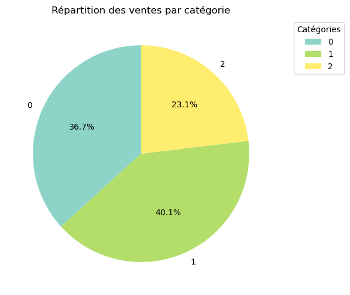

```python
ventes_par_categ = df_custom_transac_product.groupby("categ")["price"].sum()
plt.figure(figsize=(8, 6))
ventes_par_categ.plot.pie(autopct='%1.1f%%', startangle=90, cmap="Set3")
plt.legend(
    labels=ventes_par_categ.index,  # Les catégories comme labels
    title="Catégories",            # Titre de la légende
    bbox_to_anchor=(1.05, 1),      # Position à droite du graphique
    loc="upper left")


plt.ylabel("")
plt.title("Répartition des ventes par catégorie")
plt.show()
```

```python
df_custom_transac_product['price_0']=df_custom_transac_product[df_custom_transac_product.categ==0].price
df_custom_transac_product['price_1']=df_custom_transac_product[df_custom_transac_product.categ==1].price
df_custom_transac_product['price_2']=df_custom_transac_product[df_custom_transac_product.categ==2].price

df_custom_transac_product.head()
```

|  | id_prod | date | session_id | client_id | sex | birth | price | categ | month | day | age | price_0 | price_1 | price_2 |
| --- | --- | --- | --- | --- | --- | --- | --- | --- | --- | --- | --- | --- | --- | --- |
| 0 | 0_1259 | 2021-03-01 00:01:07.843138 | s_1 | c_329 | f | 1967.0 | 11.99 | 0 | 2021-03 | 2021-03-01 | 57.0 | 11.99 | NaN | NaN |
| 1 | 0_1259 | 2022-10-01 00:01:07.843138 | s_275943 | c_329 | f | 1967.0 | 11.99 | 0 | 2022-10 | 2022-10-01 | 57.0 | 11.99 | NaN | NaN |
| 2 | 0_1259 | 2022-12-01 00:01:07.843138 | s_305291 | c_329 | f | 1967.0 | 11.99 | 0 | 2022-12 | 2022-12-01 | 57.0 | 11.99 | NaN | NaN |
| 3 | 0_1259 | 2023-01-01 00:01:07.843138 | s_320153 | c_329 | f | 1967.0 | 11.99 | 0 | 2023-01 | 2023-01-01 | 57.0 | 11.99 | NaN | NaN |
| 4 | 0_1259 | 2021-03-04 07:26:01.343183 | s_1519 | c_1609 | m | 1980.0 | 11.99 | 0 | 2021-03 | 2021-03-04 | 44.0 | 11.99 | NaN | NaN |

```python
df_mois=df_custom_transac_product.groupby('month').agg(
    montant_0=('price_0', np.sum),
    montant_1=('price_1', np.sum),
    montant_2=('price_2', np.sum))

df_mois
```

| month | montant_0 | montant_1 | montant_2 |
| --- | --- | --- | --- |
| 2021-03 | 193629.17 | 186974.17 | 101837.27 |
| 2021-04 | 205222.46 | 156138.35 | 114748.49 |
| 2021-05 | 196186.72 | 165893.40 | 130863.35 |
| 2021-06 | 167943.15 | 189162.04 | 126983.37 |
| 2021-07 | 144750.79 | 188523.27 | 149561.34 |
| 2021-08 | 167737.62 | 162991.38 | 151555.79 |
| 2021-09 | 246353.91 | 190613.78 | 70272.99 |
| 2021-10 | 199250.83 | 207696.74 | 87785.59 |
| 2021-11 | 155909.56 | 252910.39 | 107347.78 |
| 2021-12 | 206036.24 | 251026.75 | 68854.29 |
| 2022-01 | 164210.51 | 256267.92 | 104860.56 |
| 2022-02 | 183197.33 | 213120.64 | 139253.53 |
| 2022-03 | 191464.94 | 206485.26 | 117506.33 |
| 2022-04 | 174997.26 | 195263.97 | 122737.71 |
| 2022-05 | 194872.34 | 205532.63 | 116727.63 |
| 2022-06 | 183934.86 | 201912.06 | 110169.20 |
| 2022-07 | 187097.00 | 193969.72 | 129716.40 |
| 2022-08 | 177372.76 | 211360.09 | 117734.42 |
| 2022-09 | 183329.24 | 195379.54 | 115405.75 |
| 2022-10 | 187429.17 | 199609.66 | 120878.94 |
| 2022-11 | 184594.35 | 200427.99 | 111642.60 |
| 2022-12 | 180470.70 | 205945.71 | 123803.09 |
| 2023-01 | 181283.06 | 210104.41 | 126153.08 |
| 2023-02 | 162457.00 | 180347.24 | 113875.52 |

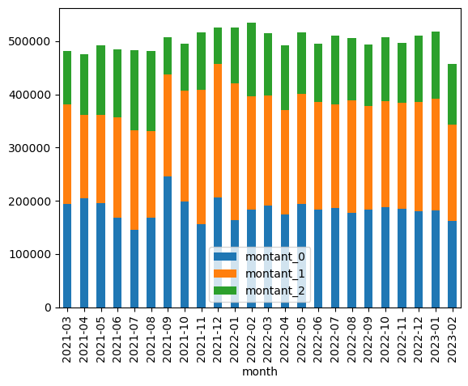

```python
df_mois.plot.bar(stacked=True)
```

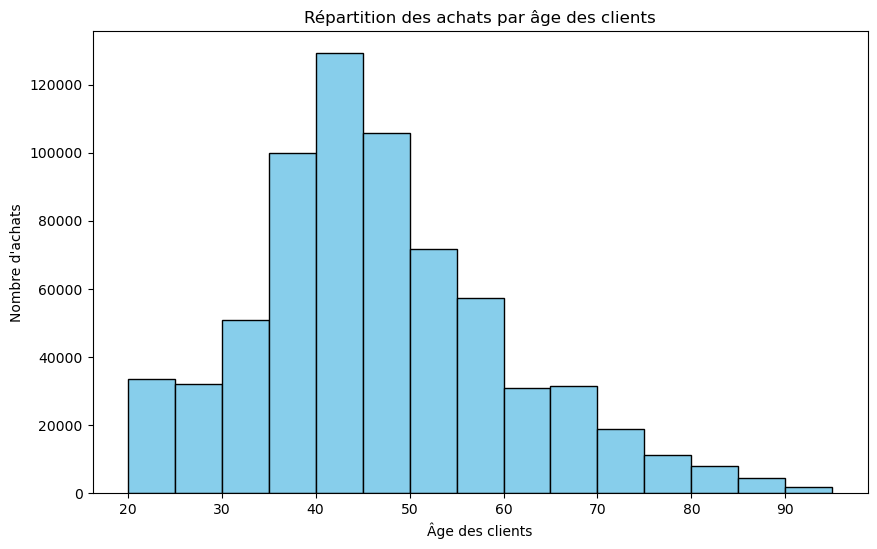

```python
plt.figure(figsize=(10, 6))
plt.hist(df_custom_transac_product["age"].dropna(), bins=15, color='skyblue', edgecolor='black')
plt.xlabel("Âge des clients")
plt.ylabel("Nombre d'achats")
plt.title("Répartition des achats par âge des clients")
plt.show()
```

### Moyenne mobile

```python
df_custom_transac_product[['0','1','2']]=pd.get_dummies(df_custom_transac_product['categ']).astype(int)
df_custom_transac_product[['m','f']]=pd.get_dummies(df_custom_transac_product['sex']).astype(int)
df_custom_transac_product.head()
```

|  | id_prod | date | session_id | client_id | sex | birth | price | categ | month | day | age | price_0 | price_1 | price_2 | 0 | 1 | 2 | m | f |
| --- | --- | --- | --- | --- | --- | --- | --- | --- | --- | --- | --- | --- | --- | --- | --- | --- | --- | --- | --- |
| 0 | 0_1259 | 2021-03-01 00:01:07.843138 | s_1 | c_329 | f | 1967.0 | 11.99 | 0 | 2021-03 | 2021-03-01 | 57.0 | 11.99 | NaN | NaN | 1 | 0 | 0 | 1 | 0 |
| 1 | 0_1259 | 2022-10-01 00:01:07.843138 | s_275943 | c_329 | f | 1967.0 | 11.99 | 0 | 2022-10 | 2022-10-01 | 57.0 | 11.99 | NaN | NaN | 1 | 0 | 0 | 1 | 0 |
| 2 | 0_1259 | 2022-12-01 00:01:07.843138 | s_305291 | c_329 | f | 1967.0 | 11.99 | 0 | 2022-12 | 2022-12-01 | 57.0 | 11.99 | NaN | NaN | 1 | 0 | 0 | 1 | 0 |
| 3 | 0_1259 | 2023-01-01 00:01:07.843138 | s_320153 | c_329 | f | 1967.0 | 11.99 | 0 | 2023-01 | 2023-01-01 | 57.0 | 11.99 | NaN | NaN | 1 | 0 | 0 | 1 | 0 |
| 4 | 0_1259 | 2021-03-04 07:26:01.343183 | s_1519 | c_1609 | m | 1980.0 | 11.99 | 0 | 2021-03 | 2021-03-04 | 44.0 | 11.99 | NaN | NaN | 1 | 0 | 0 | 0 | 1 |

```python
client_achat= df_custom_transac_product.groupby("client_id").agg(
    sex=('sex', np.max),
    age=('age', np.max),
    amount=('price', np.sum),
    count=('session_id', np.count_nonzero),
    categ_0=('0', np.count_nonzero),
    categ_1=('1', np.count_nonzero),
    categ_2=('2', np.count_nonzero))
client_achat.sort_values(by='amount',ascending=False,inplace=True)
client_achat['amount']=client_achat['amount'].apply(lambda x : "{:,.2f}".format(x))
sex={'f':0,'m':1}
client_achat['sex']=client_achat['sex'].apply(lambda x:sex.get(x,''))
client_achat.head()
```

| client_id | sex | age | amount | count | categ_0 | categ_1 | categ_2 |
| --- | --- | --- | --- | --- | --- | --- | --- |
| c_1609 | 1 | 44.0 | 326,039.89 | 25586 | 20167 | 5408 | 11 |
| c_4958 | 1 | 25.0 | 290,227.03 | 5222 | 4 | 1915 | 3303 |
| c_6714 | 0 | 56.0 | 153,918.60 | 9199 | 5310 | 3586 | 303 |
| c_3454 | 1 | 55.0 | 114,110.57 | 6793 | 2697 | 4078 | 18 |
| c_1570 | 0 | 45.0 | 5,285.82 | 370 | 260 | 109 | 1 |

```python
df_moyenne_mobile = df_custom_transac_product.groupby('month').agg(
    age=('age', np.mean),
    m=('m', np.count_nonzero),
    f=('f', np.count_nonzero),
    amount=('price', np.sum),
    avg_price=('price', np.mean),
    count=('session_id', np.count_nonzero),
    categ_0=('0', np.count_nonzero),
    categ_1=('1', np.count_nonzero),
    categ_2=('2', np.count_nonzero))

df_moyenne_mobile
```

| month | age | m | f | amount | avg_price | count | categ_0 | categ_1 | categ_2 |
| --- | --- | --- | --- | --- | --- | --- | --- | --- | --- |
| 2021-03 | 46.158666 | 14156 | 14445 | 482440.61 | 16.867963 | 28601 | 18131 | 9134 | 1336 |
| 2021-04 | 45.879935 | 14275 | 14168 | 476109.30 | 16.739068 | 28443 | 19342 | 7579 | 1522 |
| 2021-05 | 46.035637 | 14212 | 14073 | 492943.47 | 17.427734 | 28285 | 18501 | 8107 | 1677 |
| 2021-06 | 45.995196 | 13299 | 13551 | 484088.56 | 18.029369 | 26850 | 15898 | 9264 | 1688 |
| 2021-07 | 45.751475 | 12283 | 12455 | 482835.40 | 19.517964 | 24738 | 13578 | 9169 | 1991 |
| 2021-08 | 45.661209 | 12767 | 12883 | 482284.79 | 18.802526 | 25650 | 15728 | 7954 | 1968 |
| 2021-09 | 46.658072 | 16394 | 16920 | 507240.68 | 15.226052 | 33314 | 23142 | 9268 | 904 |
| 2021-10 | 45.288588 | 14898 | 15124 | 494733.16 | 16.479021 | 30022 | 18762 | 10089 | 1171 |
| 2021-11 | 46.579527 | 14056 | 14255 | 516167.73 | 18.232056 | 28311 | 14600 | 12316 | 1395 |
| 2021-12 | 46.896232 | 16142 | 16315 | 525917.28 | 16.203509 | 32457 | 19302 | 12259 | 896 |
| 2022-01 | 46.693624 | 14801 | 14542 | 525338.99 | 17.903384 | 29343 | 15397 | 12560 | 1386 |
| 2022-02 | 46.092316 | 14866 | 14728 | 535571.50 | 18.097300 | 29594 | 17281 | 10459 | 1854 |
| 2022-03 | 46.357287 | 15044 | 14652 | 515456.53 | 17.357776 | 29696 | 18045 | 10126 | 1525 |
| 2022-04 | 46.027389 | 13708 | 13894 | 492998.94 | 17.860986 | 27602 | 16465 | 9502 | 1635 |
| 2022-05 | 46.184053 | 14743 | 15232 | 517132.60 | 17.252130 | 29975 | 18408 | 10047 | 1520 |
| 2022-06 | 46.387279 | 14333 | 14171 | 496016.12 | 17.401632 | 28504 | 17271 | 9790 | 1443 |
| 2022-07 | 46.148099 | 14317 | 14353 | 510783.12 | 17.815944 | 28670 | 17502 | 9470 | 1698 |
| 2022-08 | 46.307525 | 14399 | 14145 | 506467.27 | 17.743388 | 28544 | 16650 | 10305 | 1589 |
| 2022-09 | 46.104006 | 13894 | 14412 | 494114.53 | 17.456176 | 28306 | 17225 | 9566 | 1515 |
| 2022-10 | 46.253453 | 14531 | 14433 | 507917.77 | 17.536175 | 28964 | 17664 | 9726 | 1574 |
| 2022-11 | 46.100725 | 14126 | 14437 | 496664.94 | 17.388402 | 28563 | 17309 | 9798 | 1456 |
| 2022-12 | 46.223488 | 14168 | 14451 | 510219.50 | 17.827999 | 28619 | 16935 | 10063 | 1621 |
| 2023-01 | 46.142823 | 14514 | 14424 | 517540.55 | 17.884462 | 28938 | 17068 | 10252 | 1618 |
| 2023-02 | 46.180192 | 12767 | 12778 | 456679.76 | 17.877462 | 25545 | 15255 | 8789 | 1501 |

```python
df_moyenne_mobile['amount'] = df_moyenne_mobile['amount'].apply(lambda x: "{:,.2f}".format(x))
df_moyenne_mobile['avg_price'] = df_moyenne_mobile['avg_price'].apply(lambda x: "{:,.2f}".format(x))
df_moyenne_mobile['age'] = df_moyenne_mobile['age'].apply(lambda x: "{:,.1f}".format(x))
df_moyenne_mobile.head()
```

| month | age | m | f | amount | avg_price | count | categ_0 | categ_1 | categ_2 |
| --- | --- | --- | --- | --- | --- | --- | --- | --- | --- |
| 2021-03 | 46.2 | 14156 | 14445 | 482,440.61 | 16.87 | 28601 | 18131 | 9134 | 1336 |
| 2021-04 | 45.9 | 14275 | 14168 | 476,109.30 | 16.74 | 28443 | 19342 | 7579 | 1522 |
| 2021-05 | 46.0 | 14212 | 14073 | 492,943.47 | 17.43 | 28285 | 18501 | 8107 | 1677 |
| 2021-06 | 46.0 | 13299 | 13551 | 484,088.56 | 18.03 | 26850 | 15898 | 9264 | 1688 |
| 2021-07 | 45.8 | 12283 | 12455 | 482,835.40 | 19.52 | 24738 | 13578 | 9169 | 1991 |

```python
df_montant_an = df_custom_transac_product.groupby('month').agg(amount=('price', np.sum))

df_montant_an.head()
```

| month | amount |
| --- | --- |
| 2021-03 | 482440.61 |
| 2021-04 | 476109.30 |
| 2021-05 | 492943.47 |
| 2021-06 | 484088.56 |
| 2021-07 | 482835.40 |

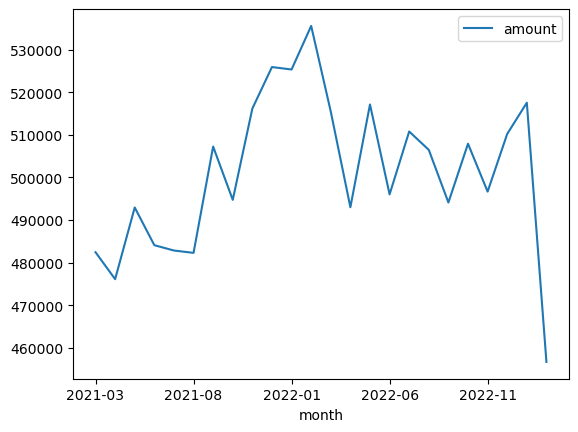

```python
df_montant_an.plot()
```

```python
df_montant_an["amount_mm3"]= df_montant_an.amount.rolling(3).mean()
df_montant_an["amount_mm5"]= df_montant_an.amount.rolling(5).mean()
df_montant_an.head()
```

| month | amount | amount_mm3 | amount_mm5 |
| --- | --- | --- | --- |
| 2021-03 | 482440.61 | NaN | NaN |
| 2021-04 | 476109.30 | NaN | NaN |
| 2021-05 | 492943.47 | 483831.126667 | NaN |
| 2021-06 | 484088.56 | 484380.443333 | NaN |
| 2021-07 | 482835.40 | 486622.476667 | 483683.468 |

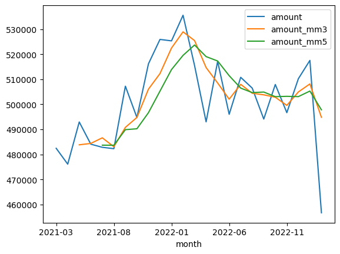

```python
df_montant_an.plot()
```

moyenne mobile courbe lisser plus facile à lire et donner les tendances (exemple courbe verte 5mois)

### Courbe de Lorenz

```python
df_custom_transac_product.head()
```

|  | id_prod | date | session_id | client_id | sex | birth | price | categ | month | day | age | price_0 | price_1 | price_2 | 0 | 1 | 2 | m | f |
| --- | --- | --- | --- | --- | --- | --- | --- | --- | --- | --- | --- | --- | --- | --- | --- | --- | --- | --- | --- |
| 0 | 0_1259 | 2021-03-01 00:01:07.843138 | s_1 | c_329 | f | 1967.0 | 11.99 | 0 | 2021-03 | 2021-03-01 | 57.0 | 11.99 | NaN | NaN | 1 | 0 | 0 | 1 | 0 |
| 1 | 0_1259 | 2022-10-01 00:01:07.843138 | s_275943 | c_329 | f | 1967.0 | 11.99 | 0 | 2022-10 | 2022-10-01 | 57.0 | 11.99 | NaN | NaN | 1 | 0 | 0 | 1 | 0 |
| 2 | 0_1259 | 2022-12-01 00:01:07.843138 | s_305291 | c_329 | f | 1967.0 | 11.99 | 0 | 2022-12 | 2022-12-01 | 57.0 | 11.99 | NaN | NaN | 1 | 0 | 0 | 1 | 0 |
| 3 | 0_1259 | 2023-01-01 00:01:07.843138 | s_320153 | c_329 | f | 1967.0 | 11.99 | 0 | 2023-01 | 2023-01-01 | 57.0 | 11.99 | NaN | NaN | 1 | 0 | 0 | 1 | 0 |
| 4 | 0_1259 | 2021-03-04 07:26:01.343183 | s_1519 | c_1609 | m | 1980.0 | 11.99 | 0 | 2021-03 | 2021-03-04 | 44.0 | 11.99 | NaN | NaN | 1 | 0 | 0 | 0 | 1 |

```python
lorenz = df_custom_transac_product.groupby('client_id').agg(CA=("price",np.sum)).reset_index()
lorenz.head()
```

|  | client_id | CA |
| --- | --- | --- |
| 0 | c_1 | 629.02 |
| 1 | c_10 | 1353.60 |
| 2 | c_100 | 254.85 |
| 3 | c_1000 | 2291.88 |
| 4 | c_1001 | 1823.85 |

```python
lorenz.sort_values("CA",inplace=True)
lorenz.head()
```

|  | client_id | CA |
| --- | --- | --- |
| 8151 | c_8351 | 6.31 |
| 7918 | c_8140 | 8.30 |
| 7889 | c_8114 | 9.98 |
| 4044 | c_4648 | 11.20 |
| 3855 | c_4478 | 13.36 |

```python
CA_total = lorenz.CA.sum()
CA_total
```

```
12027663.100000001
```

```python
lorenz["CA_percent"] = (lorenz.CA/ CA_total)*100
lorenz.head()
```

|  | client_id | CA | CA_percent |
| --- | --- | --- | --- |
| 8151 | c_8351 | 6.31 | 0.000052 |
| 7918 | c_8140 | 8.30 | 0.000069 |
| 7889 | c_8114 | 9.98 | 0.000083 |
| 4044 | c_4648 | 11.20 | 0.000093 |
| 3855 | c_4478 | 13.36 | 0.000111 |

```python
nb_client = lorenz.shape[0]
nb_client
```

```
8600
```

```python
lorenz["client_percent"]= (1/nb_client)*100
lorenz.head()
```

|  | client_id | CA | CA_percent | client_percent |
| --- | --- | --- | --- | --- |
| 8151 | c_8351 | 6.31 | 0.000052 | 0.011628 |
| 7918 | c_8140 | 8.30 | 0.000069 | 0.011628 |
| 7889 | c_8114 | 9.98 | 0.000083 | 0.011628 |
| 4044 | c_4648 | 11.20 | 0.000093 | 0.011628 |
| 3855 | c_4478 | 13.36 | 0.000111 | 0.011628 |

```python
lorenz["CA_cumul"] = lorenz.CA_percent.cumsum()
lorenz.tail()
```

|  | client_id | CA | CA_percent | client_percent | CA_cumul |
| --- | --- | --- | --- | --- | --- |
| 634 | c_1570 | 5285.82 | 0.043947 | 0.011628 | 92.647815 |
| 2724 | c_3454 | 114110.57 | 0.948734 | 0.011628 | 93.596549 |
| 6337 | c_6714 | 153918.60 | 1.279705 | 0.011628 | 94.876254 |
| 4388 | c_4958 | 290227.03 | 2.412996 | 0.011628 | 97.289250 |
| 677 | c_1609 | 326039.89 | 2.710750 | 0.011628 | 100.000000 |

```python
lorenz["client_cumul"] = lorenz.client_percent.cumsum()
lorenz.tail()
```

|  | client_id | CA | CA_percent | client_percent | CA_cumul | client_cumul |
| --- | --- | --- | --- | --- | --- | --- |
| 634 | c_1570 | 5285.82 | 0.043947 | 0.011628 | 92.647815 | 99.953488 |
| 2724 | c_3454 | 114110.57 | 0.948734 | 0.011628 | 93.596549 | 99.965116 |
| 6337 | c_6714 | 153918.60 | 1.279705 | 0.011628 | 94.876254 | 99.976744 |
| 4388 | c_4958 | 290227.03 | 2.412996 | 0.011628 | 97.289250 | 99.988372 |
| 677 | c_1609 | 326039.89 | 2.710750 | 0.011628 | 100.000000 | 100.000000 |

```python
mask_superieur80 = lorenz.client_cumul >= 80
lorenz[mask_superieur80].head()
```

|  | client_id | CA | CA_percent | client_percent | CA_cumul | client_cumul |
| --- | --- | --- | --- | --- | --- | --- |
| 4646 | c_519 | 2024.12 | 0.016829 | 0.011628 | 51.874522 | 80.011628 |
| 357 | c_1320 | 2024.64 | 0.016833 | 0.011628 | 51.891356 | 80.023256 |
| 2618 | c_3358 | 2024.98 | 0.016836 | 0.011628 | 51.908192 | 80.034884 |
| 6912 | c_7234 | 2025.51 | 0.016840 | 0.011628 | 51.925032 | 80.046512 |
| 4545 | c_5099 | 2025.80 | 0.016843 | 0.011628 | 51.941875 | 80.058140 |

```python
CA80 = lorenz[mask_superieur80].iloc[0,4]
CA80
```

```
51.87452232512239
```

```python
lorenz.tail(10)
```

|  | client_id | CA | CA_percent | client_percent | CA_cumul | client_cumul |
| --- | --- | --- | --- | --- | --- | --- |
| 7715 | c_7959 | 5135.75 | 0.042699 | 0.011628 | 92.430044 | 99.895349 |
| 7006 | c_7319 | 5155.77 | 0.042866 | 0.011628 | 92.472910 | 99.906977 |
| 2108 | c_2899 | 5214.05 | 0.043350 | 0.011628 | 92.516261 | 99.918605 |
| 1268 | c_2140 | 5260.18 | 0.043734 | 0.011628 | 92.559995 | 99.930233 |
| 2513 | c_3263 | 5276.87 | 0.043873 | 0.011628 | 92.603867 | 99.941860 |
| 634 | c_1570 | 5285.82 | 0.043947 | 0.011628 | 92.647815 | 99.953488 |
| 2724 | c_3454 | 114110.57 | 0.948734 | 0.011628 | 93.596549 | 99.965116 |
| 6337 | c_6714 | 153918.60 | 1.279705 | 0.011628 | 94.876254 | 99.976744 |
| 4388 | c_4958 | 290227.03 | 2.412996 | 0.011628 | 97.289250 | 99.988372 |
| 677 | c_1609 | 326039.89 | 2.710750 | 0.011628 | 100.000000 | 100.000000 |

```python
lorenz.tail(4).client_id
```

```
2724    c_3454
6337    c_6714
4388    c_4958
677     c_1609
Name: client_id, dtype: object
```

```python
CA_pro = lorenz.tail(4).iloc[0,4]
CA_pro
```

```
93.5965489422464
```

```python
client_pro = lorenz.tail(4).iloc[0,5]
client_pro
```

```
99.96511627905498
```

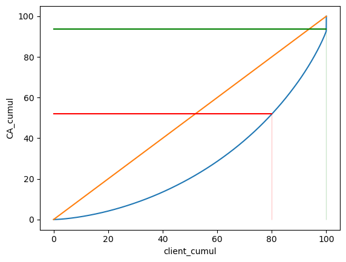

```python
sns.lineplot(data=lorenz, x="client_cumul", y="CA_cumul")
sns.lineplot(x=[0, 100], y=[0, 100])
sns.lineplot(x=[80, 80], y=[0, CA80],color='red',linewidth=2.5)
sns.lineplot(x=[80,0], y=[CA80,CA80],color='red')
sns.lineplot(x=[client_pro,client_pro], y=[0,CA_pro],color='green')
sns.lineplot(x=[0,client_pro], y=[CA_pro,CA_pro],color='green')
```

```python
client_pro = list(lorenz.tail(4).client_id)
client_pro
```

```
['c_3454', 'c_6714', 'c_4958', 'c_1609']
```

```python
mask_client_pro = df_custom_transac_product.client_id.isin(client_pro)
df_custom_transac_product[mask_client_pro]
```

|  | id_prod | date | session_id | client_id | sex | birth | price | categ | month | day | age | price_0 | price_1 | price_2 | 0 | 1 | 2 | m | f |
| --- | --- | --- | --- | --- | --- | --- | --- | --- | --- | --- | --- | --- | --- | --- | --- | --- | --- | --- | --- |
| 4 | 0_1259 | 2021-03-04 07:26:01.343183 | s_1519 | c_1609 | m | 1980.0 | 11.99 | 0 | 2021-03 | 2021-03-04 | 44.0 | 11.99 | NaN | NaN | 1 | 0 | 0 | 0 | 1 |
| 5 | 0_1259 | 2021-06-24 09:40:37.526181 | s_53058 | c_1609 | m | 1980.0 | 11.99 | 0 | 2021-06 | 2021-06-24 | 44.0 | 11.99 | NaN | NaN | 1 | 0 | 0 | 0 | 1 |
| 6 | 0_1259 | 2021-06-24 14:40:37.428842 | s_53165 | c_1609 | m | 1980.0 | 11.99 | 0 | 2021-06 | 2021-06-24 | 44.0 | 11.99 | NaN | NaN | 1 | 0 | 0 | 0 | 1 |
| 7 | 0_1259 | 2021-09-26 21:30:08.966835 | s_96014 | c_1609 | m | 1980.0 | 11.99 | 0 | 2021-09 | 2021-09-26 | 44.0 | 11.99 | NaN | NaN | 1 | 0 | 0 | 0 | 1 |
| 8 | 0_1259 | 2021-10-16 03:22:15.039429 | s_105418 | c_1609 | m | 1980.0 | 11.99 | 0 | 2021-10 | 2021-10-16 | 44.0 | 11.99 | NaN | NaN | 1 | 0 | 0 | 0 | 1 |
| ... | ... | ... | ... | ... | ... | ... | ... | ... | ... | ... | ... | ... | ... | ... | ... | ... | ... | ... | ... |
| 677247 | 0_2125 | 2022-02-20 01:08:04.464445 | s_167863 | c_6714 | f | 1968.0 | 1.99 | 0 | 2022-02 | 2022-02-20 | 56.0 | 1.99 | NaN | NaN | 1 | 0 | 0 | 1 | 0 |
| 677248 | 0_2125 | 2022-10-20 01:08:04.464445 | s_285100 | c_6714 | f | 1968.0 | 1.99 | 0 | 2022-10 | 2022-10-20 | 56.0 | 1.99 | NaN | NaN | 1 | 0 | 0 | 1 | 0 |
| 677256 | 1_266 | 2022-02-27 18:11:22.254342 | s_171810 | c_6714 | f | 1968.0 | 7.98 | 1 | 2022-02 | 2022-02-27 | 56.0 | NaN | 7.98 | NaN | 0 | 1 | 0 | 1 | 0 |
| 677257 | 1_266 | 2022-12-27 18:11:22.254342 | s_318200 | c_6714 | f | 1968.0 | 7.98 | 1 | 2022-12 | 2022-12-27 | 56.0 | NaN | 7.98 | NaN | 0 | 1 | 0 | 1 | 0 |
| 677258 | 1_266 | 2023-02-27 18:11:22.254342 | s_347842 | c_6714 | f | 1968.0 | 7.98 | 1 | 2023-02 | 2023-02-27 | 56.0 | NaN | 7.98 | NaN | 0 | 1 | 0 | 1 | 0 |

46800 rows × 19 columns

```python
df_custom_transac_product.drop(df_custom_transac_product[mask_client_pro].index, inplace=True)
df_custom_transac_product[mask_client_pro]
```

|  | id_prod | date | session_id | client_id | sex | birth | price | categ | month | day | age | price_0 | price_1 | price_2 | 0 | 1 | 2 | m | f |
| --- | --- | --- | --- | --- | --- | --- | --- | --- | --- | --- | --- | --- | --- | --- | --- | --- | --- | --- | --- |

## analyse bivariée : discrete discrete (chi2 / v cramer) / discrete continue (anova/eta) / continu continu (anova/r2)

### Corrélation genre/categorie (discret/discret)

```python
df_custom_transac_product.head()
```

|  | id_prod | date | session_id | client_id | sex | birth | price | categ | month | day | age | price_0 | price_1 | price_2 | 0 | 1 | 2 | m | f |
| --- | --- | --- | --- | --- | --- | --- | --- | --- | --- | --- | --- | --- | --- | --- | --- | --- | --- | --- | --- |
| 0 | 0_1259 | 2021-03-01 00:01:07.843138 | s_1 | c_329 | f | 1967.0 | 11.99 | 0 | 2021-03 | 2021-03-01 | 57.0 | 11.99 | NaN | NaN | 1 | 0 | 0 | 1 | 0 |
| 1 | 0_1259 | 2022-10-01 00:01:07.843138 | s_275943 | c_329 | f | 1967.0 | 11.99 | 0 | 2022-10 | 2022-10-01 | 57.0 | 11.99 | NaN | NaN | 1 | 0 | 0 | 1 | 0 |
| 2 | 0_1259 | 2022-12-01 00:01:07.843138 | s_305291 | c_329 | f | 1967.0 | 11.99 | 0 | 2022-12 | 2022-12-01 | 57.0 | 11.99 | NaN | NaN | 1 | 0 | 0 | 1 | 0 |
| 3 | 0_1259 | 2023-01-01 00:01:07.843138 | s_320153 | c_329 | f | 1967.0 | 11.99 | 0 | 2023-01 | 2023-01-01 | 57.0 | 11.99 | NaN | NaN | 1 | 0 | 0 | 1 | 0 |
| 18 | 0_1259 | 2022-01-13 11:13:57.734842 | s_149171 | c_1478 | f | 1972.0 | 11.99 | 0 | 2022-01 | 2022-01-13 | 52.0 | 11.99 | NaN | NaN | 1 | 0 | 0 | 1 | 0 |

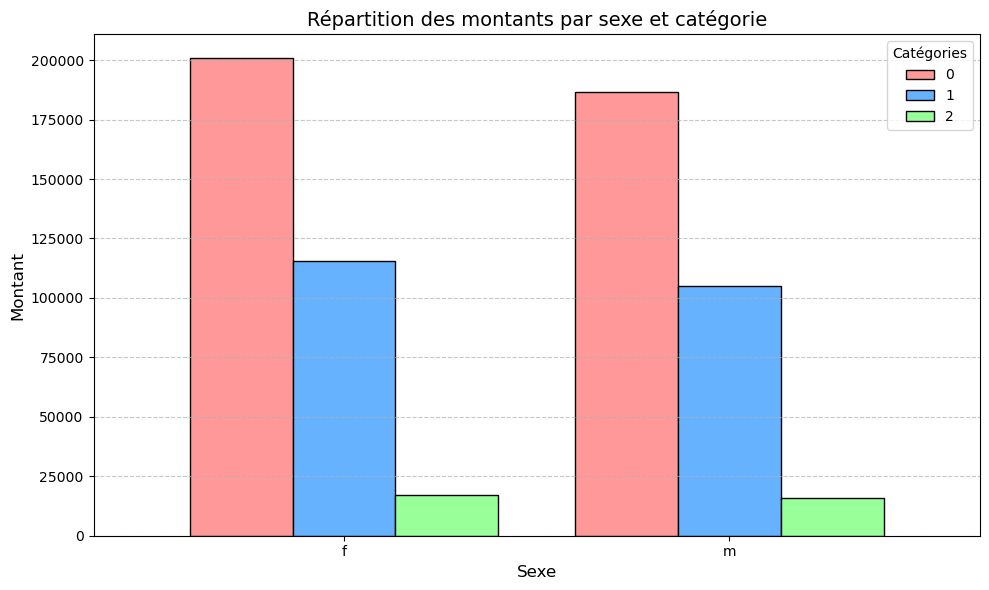

```python
crosstab.iloc[:-1,:-1].plot(
    kind='bar',
    figsize=(10, 6),
    width=0.8,
    color=['#FF9999', '#66B2FF', '#99FF99'],
    edgecolor="black")
plt.title("Répartition des montants par sexe et catégorie", fontsize=14)
plt.xlabel("Sexe", fontsize=12)
plt.ylabel("Montant", fontsize=12)
plt.xticks(rotation=0)
plt.legend(title="Catégories")
plt.grid(axis='y', linestyle='--', alpha=0.7)
plt.tight_layout()
```

```python
crosstab = pd.crosstab(df_custom_transac_product['sex'], df_custom_transac_product['categ'],margins=True)
chi, pvalue, df, expected=stats.chi2_contingency(crosstab)
pvalue
```

```
0.0009154328070695418
```

```python
chi
```

```
22.66856665178056
```

```python
pvalue
```

```
0.0009154328070695418
```

```python
expected
```

```
array([[201574.89662481, 114822.13191434,  17096.97146086,
        333494.        ],
       [185706.10337519, 105782.86808566,  15751.02853914,
        307240.        ],
       [387281.        , 220605.        ,  32848.        ,
        640734.        ]])
```

```python
df_expected = pd.DataFrame(expected, columns= crosstab.columns,index=crosstab.index)
df_expected
```

| categ sex | 0 | 1 | 2 | All |
| --- | --- | --- | --- | --- |
| f | 201574.896625 | 114822.131914 | 17096.971461 | 333494.0 |
| m | 185706.103375 | 105782.868086 | 15751.028539 | 307240.0 |
| All | 387281.000000 | 220605.000000 | 32848.000000 | 640734.0 |

```python
df_count_expected = crosstab - df_expected
df_count_expected
```

| categ sex | 0 | 1 | 2 | All |
| --- | --- | --- | --- | --- |
| f | -781.896625 | 898.868086 | -116.971461 | 0.0 |
| m | 781.896625 | -898.868086 | 116.971461 | 0.0 |
| All | 0.000000 | 0.000000 | 0.000000 | 0.0 |

```python
n = crosstab.iloc[-1,-1]
n
```

```
640734
```

```python
r = crosstab.shape[0]-1
r
```

```
2
```

```python
c = crosstab.shape[1]-1
c
```

```
3
```

```python
crosstab
```

| categ sex | 0 | 1 | 2 | All |
| --- | --- | --- | --- | --- |
| f | 200793 | 115721 | 16980 | 333494 |
| m | 186488 | 104884 | 15868 | 307240 |
| All | 387281 | 220605 | 32848 | 640734 |

```python
count=np.array(crosstab.iloc[:-1,:-1])
count
```

```
array([[200793, 115721,  16980],
       [186488, 104884,  15868]], dtype=int64)
```

```python
total1=crosstab.iloc[-1,-1]
total1
```

```
640734
```

```python
total_genre=np.array(crosstab.iloc[:-1,-1]).reshape((2,1))
total_genre
```

```
array([[333494],
       [307240]], dtype=int64)
```

```python
total_cat=np.array(crosstab.iloc[-1,:-1]).reshape((1,3))
total_cat
```

```
array([[387281, 220605,  32848]], dtype=int64)
```

```python
nij=(np.matmul(total_genre,total_cat)/total1)**0.5
nij
```

```
array([[448.97093071, 338.85414549, 130.75538788],
       [430.93631011, 325.2427833 , 125.50310171]])
```

```python
(count-expected)
```

[output not shown]

```python
expected2 = expected[:-1,:-1]
expected2
```

```
array([[201574.89662481, 114822.13191434,  17096.97146086],
       [185706.10337519, 105782.86808566,  15751.02853914]])
```

```python
(count-expected2)
```

```
array([[-781.89662481,  898.86808566, -116.97146086],
       [ 781.89662481, -898.86808566,  116.97146086]])
```

la pvalue est inferieur à 0.05, il y a donc une corrélation entre le genre et la catégorie achetée

residu standardisé = (COUNT- expected count ) / V((soustotal1*soustotal2)/total)

```python
df_expected
```

| categ sex | 0 | 1 | 2 | All |
| --- | --- | --- | --- | --- |
| f | 201574.896625 | 114822.131914 | 17096.971461 | 333494.0 |
| m | 185706.103375 | 105782.868086 | 15751.028539 | 307240.0 |
| All | 387281.000000 | 220605.000000 | 32848.000000 | 640734.0 |

```python
residu_standard = ( (crosstab.iloc[:-1, :-1] - df_expected.iloc[:-1, :-1])/ np.sqrt(
                  np.outer(crosstab.iloc[:-1, -1].values, crosstab.iloc[-1, :-1].values   ) / crosstab.iloc[-1, -1]))
residu_standard
```

| categ sex | 0 | 1 | 2 |
| --- | --- | --- | --- |
| f | -1.741531 | 2.652670 | -0.894582 |
| m | 1.814413 | -2.763683 | 0.932020 |

```python
k = min(r,c)
k
```

```
2
```

```python
v_cramer= np.sqrt(chi/(n*(k-1)))
v_cramer
```

```
0.005948029928802536
```

0.005 est une relation négligeable

```python
crosstab
```

| categ sex | 0 | 1 | 2 | All |
| --- | --- | --- | --- | --- |
| f | 200793 | 115721 | 16980 | 333494 |
| m | 186488 | 104884 | 15868 | 307240 |
| All | 387281 | 220605 | 32848 | 640734 |

```python
crosstab.All[:-1]
```

```
sex
f    333494
m    307240
Name: All, dtype: int64
```

```python
crosstab.iloc[-1,:-1]
```

```
categ
0    387281
1    220605
2     32848
Name: All, dtype: int64
```

### Corrélation Age client / categorie livre (discret/continu)

Est ce que l'âge a une influence sur la categorie de livre acheté? L'age est une variable numérique et la categorie est une variable categorique donc la procedure à suivre est la "comparaison de moyenne"avec le test central Anova

On fait un constat graphique (boite a moustache) dans un premier temps puis on verifie les prérequis (égalité des variances et normalité)

```python
df_custom_transac_product.head()
```

|  | id_prod | date | session_id | client_id | sex | birth | price | categ | month | day | age | price_0 | price_1 | price_2 | 0 | 1 | 2 | m | f |
| --- | --- | --- | --- | --- | --- | --- | --- | --- | --- | --- | --- | --- | --- | --- | --- | --- | --- | --- | --- |
| 0 | 0_1259 | 2021-03-01 00:01:07.843138 | s_1 | c_329 | f | 1967.0 | 11.99 | 0 | 2021-03 | 2021-03-01 | 57.0 | 11.99 | NaN | NaN | 1 | 0 | 0 | 1 | 0 |
| 1 | 0_1259 | 2022-10-01 00:01:07.843138 | s_275943 | c_329 | f | 1967.0 | 11.99 | 0 | 2022-10 | 2022-10-01 | 57.0 | 11.99 | NaN | NaN | 1 | 0 | 0 | 1 | 0 |
| 2 | 0_1259 | 2022-12-01 00:01:07.843138 | s_305291 | c_329 | f | 1967.0 | 11.99 | 0 | 2022-12 | 2022-12-01 | 57.0 | 11.99 | NaN | NaN | 1 | 0 | 0 | 1 | 0 |
| 3 | 0_1259 | 2023-01-01 00:01:07.843138 | s_320153 | c_329 | f | 1967.0 | 11.99 | 0 | 2023-01 | 2023-01-01 | 57.0 | 11.99 | NaN | NaN | 1 | 0 | 0 | 1 | 0 |
| 18 | 0_1259 | 2022-01-13 11:13:57.734842 | s_149171 | c_1478 | f | 1972.0 | 11.99 | 0 | 2022-01 | 2022-01-13 | 52.0 | 11.99 | NaN | NaN | 1 | 0 | 0 | 1 | 0 |

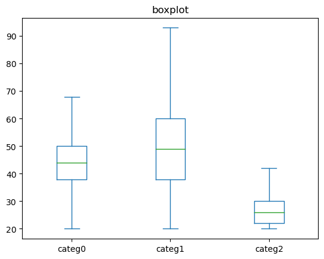

```python
# Pandas dataframedf_custom_transac_product
data = pd.DataFrame({"categ0":df_custom_transac_product[df_custom_transac_product.categ==0.0].age,
                     "categ1": df_custom_transac_product[df_custom_transac_product.categ==1.0].age,
                     "categ2": df_custom_transac_product[df_custom_transac_product.categ==2.0].age})

# Plot the dataframe
ax = data[['categ0', 'categ1',"categ2"]].plot(kind='box', title='boxplot', showfliers=False)
```

```python
stats.shapiro(df_custom_transac_product[df_custom_transac_product.categ==0].age)
```

```
ShapiroResult(statistic=0.9347574710845947, pvalue=0.0)
```

```python
stats.shapiro(df_custom_transac_product[df_custom_transac_product.categ==1].age)
```

```
ShapiroResult(statistic=0.9879432916641235, pvalue=0.0)
```

```python
stats.shapiro(df_custom_transac_product[df_custom_transac_product.categ==2].age)
```

```
ShapiroResult(statistic=0.6740533709526062, pvalue=0.0)
```

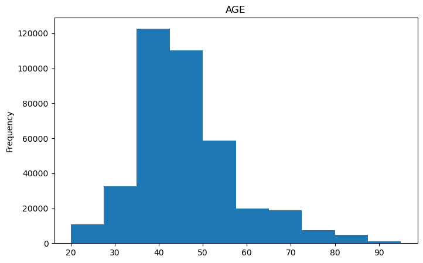

```python
ax =df_custom_transac_product[df_custom_transac_product.categ==0].age.plot(kind='hist', figsize=(8, 5), title='AGE')
```

```python
stats.levene(df_custom_transac_product[df_custom_transac_product.categ==0].age,
          df_custom_transac_product[df_custom_transac_product.categ==1].age,
          df_custom_transac_product[df_custom_transac_product.categ==2].age)
```

```
LeveneResult(statistic=24651.78036728431, pvalue=0.0)
```

Si la Pvalue est inférieure à 0.05 qui est le risque fixé, alors on rejette l'hypothèse H0. Autrement dit, l'échantillon ne suit pas la loi normale  
Si la Pvalue est supèrieure à 0.05 qui est le risque fixé, alors on maintient l'hypothèse H0. Autrement dit, l'échantillon suit la loi normale

TEST d'égalité des variances (Test de Levene):  
H0 : Les variances des sous-groupes sont toutes égales.  
H1 : Il y a au moins un sous-groupe qui a une variance différente des autres.

Si la Pvalue est inférieure à 0.05 qui est le risque fixé, alors on rejette l'hypothèse H0. Autrement dit, toutes les variances ne sont pas égales.  
Si la Pvalue est supèrieure à 0.05 qui est le risque fixé, alors on maintient l'hypothèse H0. Autrement dit, toutes les variances sont égales.

##### Les prérequis ne sont pas satisfaits, on doit donc passer le test de Kruskal (comparer des medianes) test non parametriques (pas baser sur moyenne)

TEST d'égalité des medianes Test de Kruskal Wallis:  
H0: Les medianes des sous-groupes sont toutes égales.  
H1: Il y a au moins un sous-groupe qui a une mediane différente des autres.

```python
stats.kruskal(df_custom_transac_product[df_custom_transac_product.categ==0].age,
          df_custom_transac_product[df_custom_transac_product.categ==1].age,
          df_custom_transac_product[df_custom_transac_product.categ==2].age)
```

```
KruskalResult(statistic=71359.73412120914, pvalue=0.0)
```

##### Ici, l'hypothese nulle est rejetée, on doit donc comparer les medianes afin de determiner laquelle ou lesquelles sont differentes significativement. On utilise le test Mann-Whitney

```python
stats.mannwhitneyu(df_custom_transac_product[df_custom_transac_product.categ==0].age,
          df_custom_transac_product[df_custom_transac_product.categ==1].age)
```

```
MannwhitneyuResult(statistic=35935357000.0, pvalue=0.0)
```

```python
stats.mannwhitneyu(df_custom_transac_product[df_custom_transac_product.categ==0].age,
          df_custom_transac_product[df_custom_transac_product.categ==2].age)
```

```
MannwhitneyuResult(statistic=11701564252.0, pvalue=0.0)
```

```python
stats.mannwhitneyu(df_custom_transac_product[df_custom_transac_product.categ==2].age,
          df_custom_transac_product[df_custom_transac_product.categ==1].age)
```

```
MannwhitneyuResult(statistic=822449235.0, pvalue=0.0)
```

#### Les 3 médianes sont differentes des unes des autres

```python
mediane_grp0 = np.median(df_custom_transac_product[df_custom_transac_product.categ==0].age)
mediane_grp1 = np.median(df_custom_transac_product[df_custom_transac_product.categ==1].age)
mediane_grp2 = np.median(df_custom_transac_product[df_custom_transac_product.categ==2].age)
```

```python
mediane_grp0
```

```
44.0
```

```python
mediane_grp1
```

```
49.0
```

```python
mediane_grp2
```

```
26.0
```

#### Les médianes sont différentes, l'age a une influence sur les catégories achetées. On ne peut pas determiner précisement l'influence car on ne peut passer le test Anova

### Corrélation age/taille du panier moyen (continu/continu)

```python
df_custom_transac_product.head()
```

|  | id_prod | date | session_id | client_id | sex | birth | price | categ | month | day | age | price_0 | price_1 | price_2 | 0 | 1 | 2 | m | f |
| --- | --- | --- | --- | --- | --- | --- | --- | --- | --- | --- | --- | --- | --- | --- | --- | --- | --- | --- | --- |
| 0 | 0_1259 | 2021-03-01 00:01:07.843138 | s_1 | c_329 | f | 1967.0 | 11.99 | 0 | 2021-03 | 2021-03-01 | 57.0 | 11.99 | NaN | NaN | 1 | 0 | 0 | 1 | 0 |
| 1 | 0_1259 | 2022-10-01 00:01:07.843138 | s_275943 | c_329 | f | 1967.0 | 11.99 | 0 | 2022-10 | 2022-10-01 | 57.0 | 11.99 | NaN | NaN | 1 | 0 | 0 | 1 | 0 |
| 2 | 0_1259 | 2022-12-01 00:01:07.843138 | s_305291 | c_329 | f | 1967.0 | 11.99 | 0 | 2022-12 | 2022-12-01 | 57.0 | 11.99 | NaN | NaN | 1 | 0 | 0 | 1 | 0 |
| 3 | 0_1259 | 2023-01-01 00:01:07.843138 | s_320153 | c_329 | f | 1967.0 | 11.99 | 0 | 2023-01 | 2023-01-01 | 57.0 | 11.99 | NaN | NaN | 1 | 0 | 0 | 1 | 0 |
| 18 | 0_1259 | 2022-01-13 11:13:57.734842 | s_149171 | c_1478 | f | 1972.0 | 11.99 | 0 | 2022-01 | 2022-01-13 | 52.0 | 11.99 | NaN | NaN | 1 | 0 | 0 | 1 | 0 |

Est ce que l'âge a une influence sur la taille du panier moyen?  
L'age et la taille du panier moyen(montant d'achat) sont des variables numériques

```python
df_age_achat=df_custom_transac_product.groupby('session_id').agg(
    age=('age', np.max),
    achat=('price', np.sum))
df_age_achat.head()
```

| session_id | age | achat |
| --- | --- | --- |
| s_1 | 57.0 | 11.99 |
| s_10 | 54.0 | 26.99 |
| s_100 | 46.0 | 33.72 |
| s_1000 | 35.0 | 39.22 |
| s_10000 | 35.0 | 41.49 |

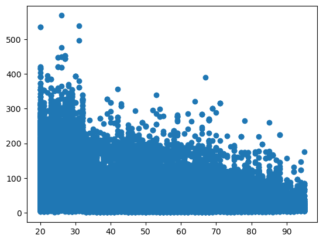

```python
plt.scatter(df_age_achat.age,df_age_achat.achat)
```

```python
df_panier_moyen=df_custom_transac_product.groupby('age').agg(
    age=('age', np.max),
    panier_moyen=("price",np.mean))


df_panier_moyen.head()
```

| age | age | panier_moyen |
| --- | --- | --- |
| 20.0 | 20.0 | 39.776612 |
| 21.0 | 21.0 | 40.231772 |
| 22.0 | 22.0 | 39.650144 |
| 23.0 | 23.0 | 41.396430 |
| 24.0 | 24.0 | 36.959170 |

```python
df_client_achat=df_custom_transac_product.groupby('client_id').agg(
    age=('age', np.max),
    achat=('price', np.sum))
df_age_achat = df_client_achat.groupby('age').agg(
    age=('age', np.max),
    achat_moyen=("achat",np.mean))
df_age_achat.head()
```

| age | age | achat_moyen |
| --- | --- | --- |
| 20.0 | 20.0 | 1410.567849 |
| 21.0 | 21.0 | 1246.075103 |
| 22.0 | 22.0 | 1288.219517 |
| 23.0 | 23.0 | 1449.868560 |
| 24.0 | 24.0 | 1230.794706 |

Ici, on voit qu'en moyenne, les personnes âgées de 20 ans depensent environ 39,78€

```python
df_panier_moyen.describe()
```

|  | age | panier_moyen |
| --- | --- | --- |
| count | 76.000000 | 76.000000 |
| mean | 57.500000 | 19.817669 |
| std | 22.083176 | 9.247698 |
| min | 20.000000 | 13.058547 |
| 25% | 38.750000 | 13.537783 |
| 50% | 57.500000 | 16.772879 |
| 75% | 76.250000 | 17.067774 |
| max | 95.000000 | 42.434323 |

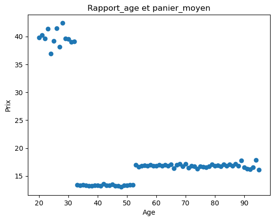

```python
plt.scatter(df_panier_moyen.age,df_panier_moyen.panier_moyen)
plt.title("Rapport_age et panier_moyen")
plt.xlabel("Age")
plt.ylabel("Prix")
plt.show()
```

Ce nuage de points nous montre qu'il n'y a pas de relation linéaire entre ces 2 variables. Nous allons donc faire une comparaison de moyenne

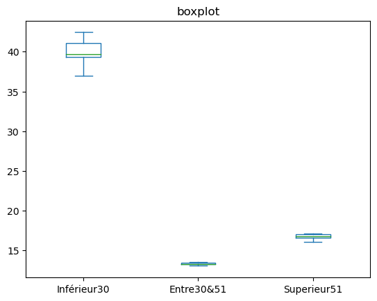

```python
# Pandas dataframe
data = pd.DataFrame({"Inférieur30":df_panier_moyen[df_panier_moyen.age<30].panier_moyen,
                     "Entre30&51": df_panier_moyen[(df_panier_moyen.age>=30)&(df_panier_moyen.age<51)].panier_moyen,
                     "Superieur51": df_panier_moyen[df_panier_moyen.age>=51].panier_moyen})

# Plot the dataframe
ax = data[['Inférieur30', 'Entre30&51',"Superieur51"]].plot(kind='box', title='boxplot', showfliers=False)
```

Si la Pvalue est inférieure à 0.05 qui est le risque fixé, alors on rejette l'hypothèse H0. Autrement dit, l'échantillon ne suit pas la loi normale  
Si la Pvalue est supèrieure à 0.05 qui est le risque fixé, alors on maintient l'hypothèse H0. Autrement dit, l'échantillon suit la loi normale

```python
import scipy.stats as st
Shapi0=st.shapiro(df_panier_moyen[df_panier_moyen.age<30].panier_moyen)
Shapi1=st.shapiro(df_panier_moyen[(df_panier_moyen.age>=30)&(df_panier_moyen.age<51)].panier_moyen)
Shapi2=st.shapiro(df_panier_moyen[df_panier_moyen.age>=51].panier_moyen)
print(Shapi0,Shapi1,Shapi2)
```

```
ShapiroResult(statistic=0.9698222279548645, pvalue=0.8891921639442444) ShapiroResult(statistic=0.43414080142974854, pvalue=5.306436889895849e-08) ShapiroResult(statistic=0.5973863005638123, pvalue=6.887908576835855e-10)
```

TEST d'égalité des variances (Test de Levene):  
H0 : Les variances des sous-groupes sont toutes égales.  
H1 : Il y a au moins un sous-groupe qui a une variance différente des autres.

Si la Pvalue est inférieure à 0.05 qui est le risque fixé, alors on rejette l'hypothèse H0. Autrement dit, toutes les variances ne sont pas égales.  
Si la Pvalue est supèrieure à 0.05 qui est le risque fixé, alors on maintient l'hypothèse H0. Autrement dit, toutes les variances sont égales.

```python
stats.levene((df_panier_moyen[df_panier_moyen.age<30].panier_moyen),
          df_panier_moyen[(df_panier_moyen.age>=30)&(df_panier_moyen.age<51)].panier_moyen,
          (df_panier_moyen[df_panier_moyen.age>=51].panier_moyen))
```

```
LeveneResult(statistic=3.454268326555037, pvalue=0.03686662758687255)
```

La Pvalue est inferieure à 0.05 les variances ne sont pas égales, il y a au moins une variance differente des autres

```python
stats.kruskal((df_panier_moyen[df_panier_moyen.age<30].panier_moyen),
          df_panier_moyen[(df_panier_moyen.age>=30)&(df_panier_moyen.age<51)].panier_moyen,
          (df_panier_moyen[df_panier_moyen.age>=51].panier_moyen))
```

```
KruskalResult(statistic=39.82982781629397, pvalue=2.244206325400614e-09)
```

##### Ici, l'hypothese nulle est rejetée, on doit donc comparer les medianes afin de determiner laquelle ou lesquelles sont differentes significativement. On utilise le test Mann-Whitney

```python
stats.mannwhitneyu((df_panier_moyen[df_panier_moyen.age<30].panier_moyen),
                   df_panier_moyen[(df_panier_moyen.age>=30)&(df_panier_moyen.age<51)].panier_moyen)
```

```
MannwhitneyuResult(statistic=203.0, pvalue=3.7866363385722595e-05)
```

```python
stats.mannwhitneyu((df_panier_moyen[df_panier_moyen.age<30].panier_moyen),
                    (df_panier_moyen[df_panier_moyen.age>=51].panier_moyen))
```

```
MannwhitneyuResult(statistic=450.0, pvalue=9.632974454581526e-07)
```

```python
stats.mannwhitneyu((df_panier_moyen[(df_panier_moyen.age>=30)&(df_panier_moyen.age<51)].panier_moyen),
                   (df_panier_moyen[df_panier_moyen.age>=51].panier_moyen))
```

```
MannwhitneyuResult(statistic=142.0, pvalue=5.543579790301639e-06)
```

```python
mediane_moins30 = np.median(df_panier_moyen[df_panier_moyen.age<30].panier_moyen)
mediane_30_51 = np.median(df_panier_moyen[(df_panier_moyen.age>=30)&(df_panier_moyen.age<51)].panier_moyen)
mediane_plus51 = np.median(df_panier_moyen[df_panier_moyen.age>=51].panier_moyen)
```

```python
mediane_moins30
```

```
39.71337797263628
```

```python
mediane_30_51
```

```
13.301348429014741
```

```python
mediane_plus51
```

```
16.799474789915966
```

#### Les médianes sont différentes, l'age a une influence sur la taille du panier moyen. On ne peut pas determiner précisement l'influence car on ne peut passer le test Anova

#### Corrélation (age/montant total des achats)

```python
df_client_achat=df_custom_transac_product.groupby('client_id').agg(
    age=('age', np.max),
    achat=('price', np.sum))
df_age_achat = df_client_achat.groupby('age').agg(
    age=('age', np.max),
    achat_moyen=("achat",np.mean))
df_age_achat.head()
```

| age | age | achat_moyen |
| --- | --- | --- |
| 20.0 | 20.0 | 1410.567849 |
| 21.0 | 21.0 | 1246.075103 |
| 22.0 | 22.0 | 1288.219517 |
| 23.0 | 23.0 | 1449.868560 |
| 24.0 | 24.0 | 1230.794706 |

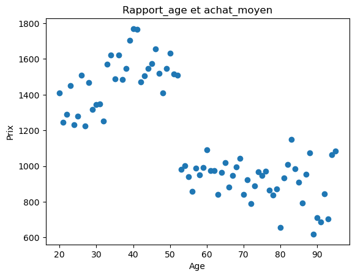

```python
plt.scatter(df_age_achat.age,df_age_achat.achat_moyen)
plt.title("Rapport_age et achat_moyen")
plt.xlabel("Age")
plt.ylabel("Prix")
plt.show()
```

```python
mask_51moins = df_age_achat.age <= 51
df_age_achat[mask_51moins].head()
```

| age | age | achat_moyen |
| --- | --- | --- |
| 20.0 | 20.0 | 1410.567849 |
| 21.0 | 21.0 | 1246.075103 |
| 22.0 | 22.0 | 1288.219517 |
| 23.0 | 23.0 | 1449.868560 |
| 24.0 | 24.0 | 1230.794706 |

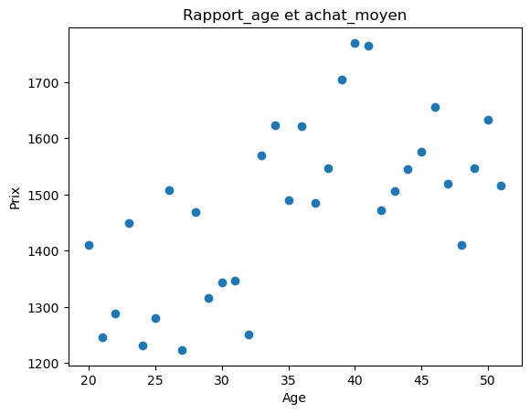

```python
plt.scatter(df_age_achat[mask_51moins].age,df_age_achat[mask_51moins].achat_moyen)
plt.title("Rapport_age et achat_moyen")
plt.xlabel("Age")
plt.ylabel("Prix")
plt.show()
```

achat moyen = A * age + B + error Test pour voir si A est different de 0 (utilisation de Anova)

Hypotese 0 (en regression) : A = 0  
Hypothese 1 : A different de 0 il y a une relation

R-squared : R2

```python
import statsmodels.api as sm
df_age_achat['intercept']=1
lm=sm.OLS(df_age_achat[mask_51moins]['achat_moyen'],df_age_achat[mask_51moins][['age','intercept']])
results=lm.fit()
results.summary()
```

OLS Regression Results

| Dep. Variable: | achat_moyen | R-squared: | 0.387 |
| --- | --- | --- | --- |
| Model: | OLS | Adj. R-squared: | 0.367 |
| Method: | Least Squares | F-statistic: | 18.95 |
| Date: | Fri, 03 Jan 2025 | Prob (F-statistic): | 0.000143 |
| Time: | 14:57:05 | Log-Likelihood: | -198.17 |
| No. Observations: | 32 | AIC: | 400.3 |
| Df Residuals: | 30 | BIC: | 403.3 |
| Df Model: | 1 |  |  |
| Covariance Type: | nonrobust |  |  |

|  | coef | std err | t | P>\|t\| | [0.025 | 0.975] |
| --- | --- | --- | --- | --- | --- | --- |
| age | 10.1904 | 2.341 | 4.354 | 0.000 | 5.410 | 14.971 |
| intercept | 1116.9989 | 85.861 | 13.009 | 0.000 | 941.648 | 1292.350 |

| Omnibus: | 1.799 | Durbin-Watson: | 1.540 |
| --- | --- | --- | --- |
| Prob(Omnibus): | 0.407 | Jarque-Bera (JB): | 1.446 |
| Skew: | 0.346 | Prob(JB): | 0.485 |
| Kurtosis: | 2.221 | Cond. No. | 146. |

Notes:  
[1] Standard Errors assume that the covariance matrix of the errors is correctly specified.

```python
st.shapiro(results.resid)
```

```
ShapiroResult(statistic=0.9625106453895569, pvalue=0.32126596570014954)
```

l'erreur suit une loi normale, le modele est valide, donc possibilité de faire des prévisions

```python
st.pearsonr(df_age_achat[mask_51moins]['achat_moyen'],df_age_achat[mask_51moins]['age'])
```

```
PearsonRResult(statistic=0.6222296024112537, pvalue=0.0001433798245864757)
```

```python
age=35
x=results.get_prediction([age,1])
x.summary_frame(0.05)
```

|  | mean | mean_se | mean_ci_lower | mean_ci_upper | obs_ci_lower | obs_ci_upper |
| --- | --- | --- | --- | --- | --- | --- |
| 0 | 1473.664257 | 21.643861 | 1429.461596 | 1517.866918 | 1220.099541 | 1727.228974 |

a 35ans on s'attend en moyenne a voir des depenses de 1473.664257 dans un intervalle de confiance à 95%.

### Corrélation age/ frequence achat

```python
df_custom_transac_product.head()
```

|  | id_prod | date | session_id | client_id | sex | birth | price | categ | month | day | age | price_0 | price_1 | price_2 | 0 | 1 | 2 | m | f |
| --- | --- | --- | --- | --- | --- | --- | --- | --- | --- | --- | --- | --- | --- | --- | --- | --- | --- | --- | --- |
| 0 | 0_1259 | 2021-03-01 00:01:07.843138 | s_1 | c_329 | f | 1967.0 | 11.99 | 0 | 2021-03 | 2021-03-01 | 57.0 | 11.99 | NaN | NaN | 1 | 0 | 0 | 1 | 0 |
| 1 | 0_1259 | 2022-10-01 00:01:07.843138 | s_275943 | c_329 | f | 1967.0 | 11.99 | 0 | 2022-10 | 2022-10-01 | 57.0 | 11.99 | NaN | NaN | 1 | 0 | 0 | 1 | 0 |
| 2 | 0_1259 | 2022-12-01 00:01:07.843138 | s_305291 | c_329 | f | 1967.0 | 11.99 | 0 | 2022-12 | 2022-12-01 | 57.0 | 11.99 | NaN | NaN | 1 | 0 | 0 | 1 | 0 |
| 3 | 0_1259 | 2023-01-01 00:01:07.843138 | s_320153 | c_329 | f | 1967.0 | 11.99 | 0 | 2023-01 | 2023-01-01 | 57.0 | 11.99 | NaN | NaN | 1 | 0 | 0 | 1 | 0 |
| 18 | 0_1259 | 2022-01-13 11:13:57.734842 | s_149171 | c_1478 | f | 1972.0 | 11.99 | 0 | 2022-01 | 2022-01-13 | 52.0 | 11.99 | NaN | NaN | 1 | 0 | 0 | 1 | 0 |

```python
df_frequence=df_custom_transac_product.groupby('client_id').agg(
    sex=('sex', np.max),
    age=('age', np.max),
    montant=('price', np.sum),
   nombre_session=('session_id', np.count_nonzero))

df_frequence.sort_values(by="montant", inplace=True, ascending=False)
df_frequence.head(10)
```

| client_id | sex | age | montant | nombre_session |
| --- | --- | --- | --- | --- |
| c_1570 | f | 45.0 | 5285.82 | 370 |
| c_3263 | f | 39.0 | 5276.87 | 403 |
| c_2140 | f | 47.0 | 5260.18 | 405 |
| c_2899 | f | 30.0 | 5214.05 | 105 |
| c_7319 | f | 50.0 | 5155.77 | 371 |
| c_7959 | f | 50.0 | 5135.75 | 372 |
| c_1422 | f | 44.0 | 5131.36 | 379 |
| c_7421 | m | 46.0 | 5097.18 | 381 |
| c_8026 | m | 46.0 | 5082.58 | 376 |
| c_2505 | f | 42.0 | 5059.35 | 366 |

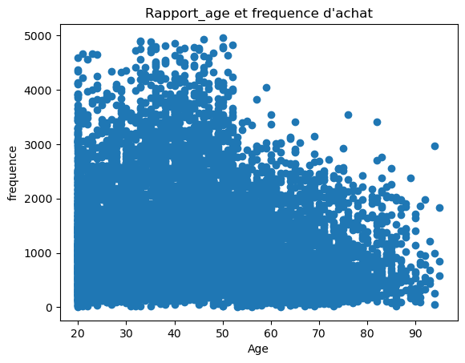

```python
plt.scatter(df_frequence[df_frequence["montant"]<5000].age,df_frequence[df_frequence["montant"]<5000]["montant"])
plt.title("Rapport_age et frequence d'achat")
plt.xlabel("Age")
plt.ylabel("frequence")
plt.show()
```

```python
df_inferieur=(df_frequence[df_frequence["montant"]<5000].groupby('age').agg(montant=("montant",np.mean)))
df_inferieur.reset_index(inplace=True)
df_inferieur.head()
```

|  | age | montant |
| --- | --- | --- |
| 0 | 20.0 | 1410.567849 |
| 1 | 21.0 | 1246.075103 |
| 2 | 22.0 | 1288.219517 |
| 3 | 23.0 | 1449.868560 |
| 4 | 24.0 | 1230.794706 |

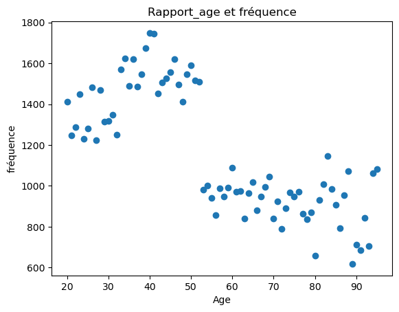

```python
plt.scatter(df_inferieur.age,df_inferieur["montant"])
plt.title("Rapport_age et fréquence")
plt.xlabel("Age")
plt.ylabel("fréquence")
plt.show()
```

Absence de relation linéaire, pas de régression linéaire possible. Nous allons procéder à une comparaison de moyenne

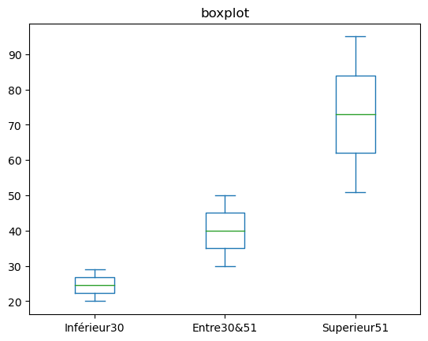

```python
data = pd.DataFrame({"Inférieur30":df_inferieur[df_inferieur.age<30].age,
                     "Entre30&51": df_inferieur[(df_inferieur.age>=30)&(df_inferieur.age<51)].age,
                     "Superieur51": df_inferieur[df_inferieur.age>=51].age})

# Plot the dataframe
ax = data[['Inférieur30', 'Entre30&51',"Superieur51"]].plot(kind='box', title='boxplot', showfliers=False)
```

```python
import scipy.stats as st
Shapi0=st.shapiro(df_inferieur[df_inferieur.age<30].age)
Shapi1=st.shapiro(df_inferieur[(df_inferieur.age>=30)&(df_inferieur.age<51)].age)
Shapi2=st.shapiro(df_inferieur[df_inferieur.age>=51].age)
print(Shapi0,Shapi1,Shapi2)
```

```
ShapiroResult(statistic=0.9701647162437439, pvalue=0.8923683762550354) ShapiroResult(statistic=0.9599329829216003, pvalue=0.5147751569747925) ShapiroResult(statistic=0.9558491706848145, pvalue=0.08479287475347519)
```

```python
st.kruskal(df_inferieur[df_inferieur.age<30].age,
           df_inferieur[(df_inferieur.age>=30)&(df_inferieur.age<51)].age,
           df_inferieur[df_inferieur.age>=51].age)
```

```
KruskalResult(statistic=57.68796992481202, pvalue=2.9731477692065644e-13)
```

L'hypothese est rejetée, on doit comparer les médianes

```python
stats.mannwhitneyu((df_inferieur[df_inferieur.age<30].age),
                   df_inferieur[(df_inferieur.age>=30)&(df_inferieur.age<51)].age)
```

```
MannwhitneyuResult(statistic=0.0, pvalue=1.0057617417080973e-05)
```

```python
stats.mannwhitneyu((df_inferieur[df_inferieur.age>=51].age),
                   df_inferieur[(df_inferieur.age>=30)&(df_inferieur.age<51)].age)
```

```
MannwhitneyuResult(statistic=945.0, pvalue=8.139796869254052e-11)
```

```python
stats.mannwhitneyu((df_inferieur[df_inferieur.age<30].age),
                   df_inferieur[(df_inferieur.age>=51)].age)
```

```
MannwhitneyuResult(statistic=0.0, pvalue=9.632974454581526e-07)
```

### top10

```python
best_prod = df_custom_transac_product.id_prod.count()
best_prod
```

```
640734
```

```python
best_prod = df_custom_transac_product.groupby('id_prod').agg(amount=('price', np.sum)).sort_values(by="amount",ascending=False)
best_prod.head(10)
```

| id_prod | amount |
| --- | --- |
| 2_159 | 91097.76 |
| 2_135 | 63470.80 |
| 2_112 | 58785.90 |
| 2_102 | 55650.74 |
| 1_369 | 52897.95 |
| 1_395 | 52182.00 |
| 2_209 | 50742.75 |
| 1_414 | 50376.62 |
| 1_383 | 49746.84 |
| 2_166 | 48308.40 |

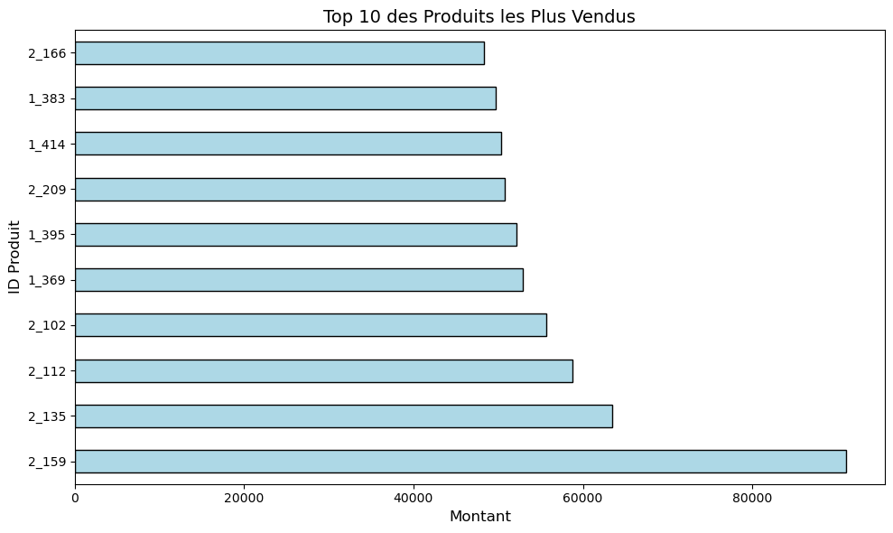

```python
plt.figure(figsize=(10, 6))
best_prod.head(10)['amount'].plot(kind='barh', color='lightblue', edgecolor='black')
plt.title('Top 10 des Produits les Plus Vendus', fontsize=14)
plt.xlabel('Montant', fontsize=12)
plt.ylabel('ID Produit', fontsize=12)
plt.tight_layout()
plt.show()
```

```python
best_prod.tail(10)
```

| id_prod | amount |
| --- | --- |
| 0_1728 | 2.27 |
| 0_1601 | 1.99 |
| 0_807 | 1.99 |
| 0_1871 | 1.99 |
| 0_541 | 1.99 |
| 0_1653 | 1.98 |
| 0_1726 | 1.57 |
| 0_1284 | 1.38 |
| 0_1191 | 0.99 |
| 0_1539 | 0.99 |

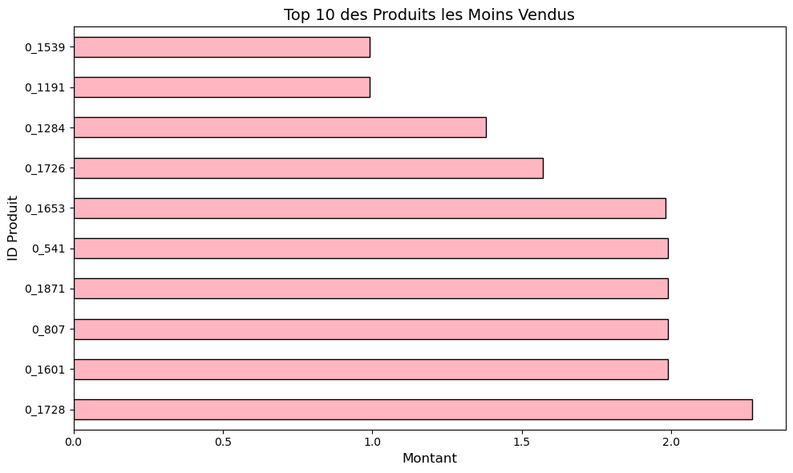

```python
plt.figure(figsize=(10, 6))
best_prod.tail(10)['amount'].plot(kind='barh', color='lightpink', edgecolor='black')
plt.title('Top 10 des Produits les Moins Vendus', fontsize=14)
plt.xlabel('Montant', fontsize=12)
plt.ylabel('ID Produit', fontsize=12)
plt.tight_layout()
plt.show()
```

```python
df_custom_transac_product.head()
```

|  | id_prod | date | session_id | client_id | sex | birth | price | categ | month | day | age | price_0 | price_1 | price_2 | 0 | 1 | 2 | m | f |
| --- | --- | --- | --- | --- | --- | --- | --- | --- | --- | --- | --- | --- | --- | --- | --- | --- | --- | --- | --- |
| 0 | 0_1259 | 2021-03-01 00:01:07.843138 | s_1 | c_329 | f | 1967.0 | 11.99 | 0 | 2021-03 | 2021-03-01 | 57.0 | 11.99 | NaN | NaN | 1 | 0 | 0 | 1 | 0 |
| 1 | 0_1259 | 2022-10-01 00:01:07.843138 | s_275943 | c_329 | f | 1967.0 | 11.99 | 0 | 2022-10 | 2022-10-01 | 57.0 | 11.99 | NaN | NaN | 1 | 0 | 0 | 1 | 0 |
| 2 | 0_1259 | 2022-12-01 00:01:07.843138 | s_305291 | c_329 | f | 1967.0 | 11.99 | 0 | 2022-12 | 2022-12-01 | 57.0 | 11.99 | NaN | NaN | 1 | 0 | 0 | 1 | 0 |
| 3 | 0_1259 | 2023-01-01 00:01:07.843138 | s_320153 | c_329 | f | 1967.0 | 11.99 | 0 | 2023-01 | 2023-01-01 | 57.0 | 11.99 | NaN | NaN | 1 | 0 | 0 | 1 | 0 |
| 18 | 0_1259 | 2022-01-13 11:13:57.734842 | s_149171 | c_1478 | f | 1972.0 | 11.99 | 0 | 2022-01 | 2022-01-13 | 52.0 | 11.99 | NaN | NaN | 1 | 0 | 0 | 1 | 0 |

```python
df_panier = df_custom_transac_product.groupby(['age', 'session_id']).agg( total_articles=('id_prod', 'count') ).reset_index()
df_panier.head()
```

|  | age | session_id | total_articles |
| --- | --- | --- | --- |
| 0 | 20.0 | s_100023 | 1 |
| 1 | 20.0 | s_100056 | 1 |
| 2 | 20.0 | s_100057 | 1 |
| 3 | 20.0 | s_100080 | 1 |
| 4 | 20.0 | s_100084 | 1 |

```python
panier_moyen = df_panier.groupby('age').agg( moyenne_article=('total_articles', np.mean))
panier_moyen.head(10)
```

| age | moyenne_article |
| --- | --- |
| 20.0 | 1.769872 |
| 21.0 | 1.717400 |
| 22.0 | 1.767067 |
| 23.0 | 1.759646 |
| 24.0 | 1.829160 |
| 25.0 | 1.789127 |
| 26.0 | 1.741181 |
| 27.0 | 1.869649 |
| 28.0 | 1.709517 |
| 29.0 | 1.788177 |

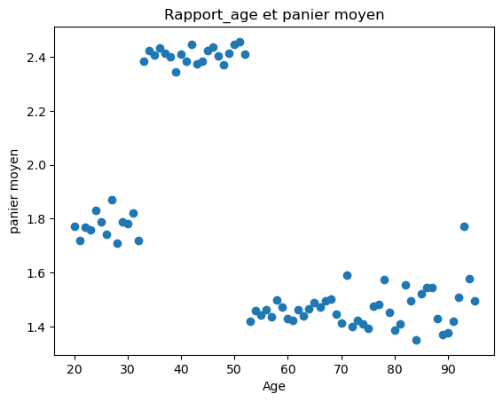

```python
plt.scatter(panier_moyen.index,panier_moyen["moyenne_article"])
plt.title("Rapport_age et panier moyen")
plt.xlabel("Age")
plt.ylabel("panier moyen")
plt.show()
```